# 16.3_KNN_multi_labeled_classification

## K-Nearest Neighbours (An instance-based learning or lazy learning)

- Unlike model based learning, instance-based learning will store training data and pospone generalization until a new instance is required to be classified or predicted.
- KNN can be used for both classification and regression predictive problems. However, it is more widely used in classification problems
- Below picture depicts how KNN algorithm works.

[figure not shown]

- The distance between the new instance and the records is calculated using euclidean distance $\sqrt{(x_1 - p_1)^2 + (x_2 - p_2)^2 + ... + (x_n - p_n)^2}$
- It is important to normalize the data, as KNN looks at the distances. If data is scalled, the distances will be appropriate.
- **Use learning curve to choose K.**

```python
import pandas as pd
import numpy as np
import matplotlib.pyplot as plt
% matplotlib inline
import seaborn as sns
from sklearn.base import BaseEstimator, TransformerMixin
from sklearn.pipeline import Pipeline
from sklearn.preprocessing import MinMaxScaler
from sklearn.model_selection import GridSearchCV

plt.rcParams['axes.labelsize'] = 14
plt.rcParams['xtick.labelsize'] = 12
plt.rcParams['ytick.labelsize'] = 12
import warnings
warnings.filterwarnings('ignore')

import random
random.seed(10)
```

```python
emotion_dataset = pd.read_csv('../data/emotions.csv')
```

### The dataset emotions is from music data set contains 72 music features for 593 songs categorized into one or more out of 6 classes of emotions.

```python
emotion_dataset.head()
```

|  | Mean_Acc1298_Mean_Mem40_Centroid | Mean_Acc1298_Mean_Mem40_Rolloff | Mean_Acc1298_Mean_Mem40_Flux | Mean_Acc1298_Mean_Mem40_MFCC_0 | Mean_Acc1298_Mean_Mem40_MFCC_1 | Mean_Acc1298_Mean_Mem40_MFCC_2 | Mean_Acc1298_Mean_Mem40_MFCC_3 | Mean_Acc1298_Mean_Mem40_MFCC_4 | Mean_Acc1298_Mean_Mem40_MFCC_5 | Mean_Acc1298_Mean_Mem40_MFCC_6 | ... | BH_HighLowRatio | BHSUM1 | BHSUM2 | BHSUM3 | amazed-suprised | happy-pleased | relaxing-calm | quiet-still | sad-lonely | angry-aggresive |
| --- | --- | --- | --- | --- | --- | --- | --- | --- | --- | --- | --- | --- | --- | --- | --- | --- | --- | --- | --- | --- | --- |
| 0 | 0.034741 | 0.089665 | 0.091225 | -73.302422 | 6.215179 | 0.615074 | 2.037160 | 0.804065 | 1.301409 | 0.558576 | ... | 2 | 0.245457 | 0.105065 | 0.405399 | 0 | 1 | 1 | 0 | 0 | 0 |
| 1 | 0.081374 | 0.272747 | 0.085733 | -62.584437 | 3.183163 | -0.218145 | 0.163038 | 0.620251 | 0.458514 | 0.041426 | ... | 2 | 0.343547 | 0.276366 | 0.710924 | 1 | 0 | 0 | 0 | 0 | 1 |
| 2 | 0.110545 | 0.273567 | 0.084410 | -65.235325 | 2.794964 | 0.639047 | 1.281297 | 0.757896 | 0.489412 | 0.627636 | ... | 3 | 0.188693 | 0.045941 | 0.457372 | 0 | 1 | 0 | 0 | 0 | 1 |
| 3 | 0.042481 | 0.199281 | 0.093447 | -80.305152 | 5.824409 | 0.648848 | 1.754870 | 1.495532 | 0.739909 | 0.809644 | ... | 2 | 0.102839 | 0.241934 | 0.351009 | 0 | 0 | 1 | 0 | 0 | 0 |
| 4 | 0.074550 | 0.140880 | 0.079789 | -93.697749 | 5.543229 | 1.064262 | 0.899152 | 0.890336 | 0.702328 | 0.490685 | ... | 2 | 0.195196 | 0.310801 | 0.683817 | 0 | 0 | 0 | 1 | 0 | 0 |

5 rows × 78 columns

```python
emotion_dataset.isnull().any().value_counts()
```

```
False    78
dtype: int64
```

```python
emotion_X = emotion_dataset.iloc[:, :-6]
multi_label_emotion_y = emotion_dataset.iloc[:, -6:]
```

```python
print(emotion_X.shape)
print(type(emotion_X))
print(multi_label_emotion_y.shape)
print(type(multi_label_emotion_y))
```

```
(593, 72)
<class 'pandas.core.frame.DataFrame'>
(593, 6)
<class 'pandas.core.frame.DataFrame'>
```

## Multi-Label Classifier:

- A classifier outputting multiple labels for each instance (or record). Examples: Face recognition classifier, tries to identify faces of different people in a single photograph.
- **In emotions dataset has 6 labels - "amazed-suprised", "happy-pleased", "relaxing-calm", "quiet-still", "sad-lonely", "angry-aggresive".**

```python
multi_label_emotion_y.head()
```

|  | amazed-suprised | happy-pleased | relaxing-calm | quiet-still | sad-lonely | angry-aggresive |
| --- | --- | --- | --- | --- | --- | --- |
| 0 | 0 | 1 | 1 | 0 | 0 | 0 |
| 1 | 1 | 0 | 0 | 0 | 0 | 1 |
| 2 | 0 | 1 | 0 | 0 | 0 | 1 |
| 3 | 0 | 0 | 1 | 0 | 0 | 0 |
| 4 | 0 | 0 | 0 | 1 | 0 | 0 |

```python
# By default train_test_split does STRATIFIED split based on label (y-value).
from sklearn.model_selection import train_test_split
emotion_X_train, emotion_X_test, multi_lable_y_train, multi_lable_y_test = train_test_split(emotion_X, multi_label_emotion_y, test_size=0.2)
```

```python
pipeline_min_max_scale = Pipeline([
    ('minMaxScaler', MinMaxScaler())
])
```

```python
emotion_X_train = pipeline_min_max_scale.fit_transform(emotion_X_train)
```

```python
from sklearn.neighbors import KNeighborsClassifier
knn_clf = KNeighborsClassifier(n_neighbors=3)
knn_clf.fit(emotion_X_train, multi_lable_y_train)
```

```
KNeighborsClassifier(algorithm='auto', leaf_size=30, metric='minkowski',
           metric_params=None, n_jobs=1, n_neighbors=3, p=2,
           weights='uniform')
```

```python
y_pred =knn_clf.predict(emotion_X_train)
```

```python
f1_score(multi_lable_y_train, y_pred, average="weighted")
```

```
0.80394576266075868
```

### Error Analysis and choosing K

- One of the ways to evaluate Mulit-Label classifier is to calulate F1-Score for each label, and then average all these (f1_score with average = 'macro'). This is not be best approach as it will not consider the label weights (number of rows with label > 5 vs number of odd labels) and will not account for label imbalance (this problem can be addressed with f1_score with average = 'weighted').

```python
from sklearn.model_selection import cross_val_predict
from sklearn.model_selection import cross_val_score
from sklearn.metrics import f1_score
y_train_knn_pred = cross_val_predict(knn_clf, emotion_X_train, multi_lable_y_train, cv=10)
f1_score(multi_lable_y_train, y_train_knn_pred, average="weighted")
```

```
0.64667552755873825
```

```python
y_train_knn_pred
```

```
array([[0, 0, 0, 0, 0, 1],
       [0, 1, 0, 0, 0, 0],
       [0, 0, 0, 1, 1, 0],
       ...,
       [0, 0, 1, 0, 0, 0],
       [1, 0, 0, 0, 0, 0],
       [0, 1, 1, 0, 0, 0]])
```

### Choose K : Learning curve

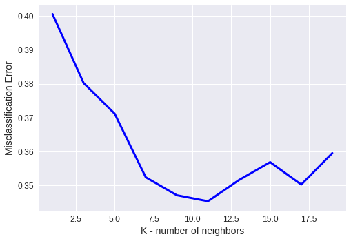

```python
mis_cls_err = []
k_neighbor = []
for k in range(1,21, 2):
    knn_clf_cv = KNeighborsClassifier(n_neighbors=k)
    scores = cross_val_score(knn_clf_cv, emotion_X_train, multi_lable_y_train, cv=10, scoring='f1_weighted')
    mse = 1 - scores.mean() # changing to misclassification error
    mis_cls_err.append(mse)
    k_neighbor.append(k)
plt.plot(k_neighbor, mis_cls_err, "b-", linewidth=3, label="val")
plt.xlabel("K - number of neighbors", fontsize=14)
plt.ylabel("Misclassification Error", fontsize=14)
```

### From above graph K= 11 is the best model

```python
knn_clf_best = KNeighborsClassifier(n_neighbors=11)
y_train_knn_pred = cross_val_predict(knn_clf_best, emotion_X_train, multi_lable_y_train, cv=10)
f1_score(multi_lable_y_train, y_train_knn_pred, average="weighted")
```

```
0.65633074702266425
```

## Now we have check root cause for inacurate classification. Is this due to less data ?, or KNN algorithm is unable to understand patterns in data?.

```python
def plot_learning_curves(model, X, y):
    X_train, X_val, y_train, y_val = train_test_split(X, y, test_size=0.2, random_state=10)
    train_error, val_error, sample_size = [], [], []
    for m in range(11, len(X_train)):
        model.fit(X_train[:m], y_train[:m])
        y_train_predict = model.predict(X_train[:m])
        y_val_predict = model.predict(X_val)

        train_f = f1_score(y_train_predict, y_train[:m], average="weighted")
        train_error.append(1 - train_f)

        val_f = f1_score(y_val_predict, y_val, average="weighted")
        val_error.append(1 - val_f)

        sample_size.append(m)

    plt.plot(sample_size, train_error, "r-+", linewidth=2, label="train")
    plt.plot(sample_size, val_error, "b-", linewidth=3, label="val")
    plt.legend(loc="bottom right", fontsize=14)
    plt.xlabel("Training set size", fontsize=14)
    plt.ylabel("F1-Score", fontsize=14)
```

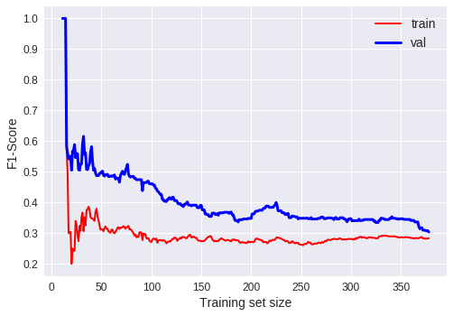

```python
plot_learning_curves(knn_clf_best, emotion_X_train, multi_lable_y_train)
```

## The Gap between train and validation error is reducing with the number of samples, hence we can understand that if we get more data, the KNN algorithm will work better.